# Chapter 7: Data and the plug-in principle

## Extra: More modern graphs

The most widely used add-on graphics package for R is `ggplot2` (note the 2):

```r
# install.packages("ggplot2")
library(ggplot2)
```

The main plotting function is `ggplot()` (note: no 2.) It requires that you specify a data frame and *aesthetics*, e.g. your x-variable within the `ggplot()` call. Then specify what kind of graph you want to draw, e.g. `geom_density()` for a kernel density plot:

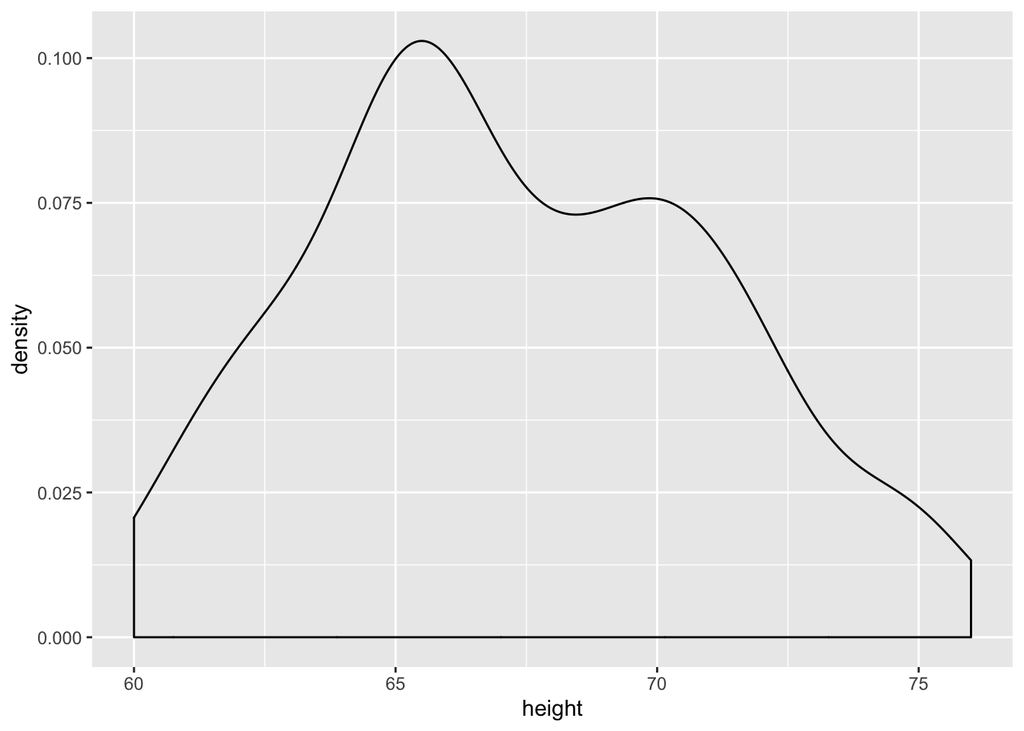

```r
ggplot(singer, aes(x = height)) + geom_density()
```

For a labeled boxplot with suppressed outliers:

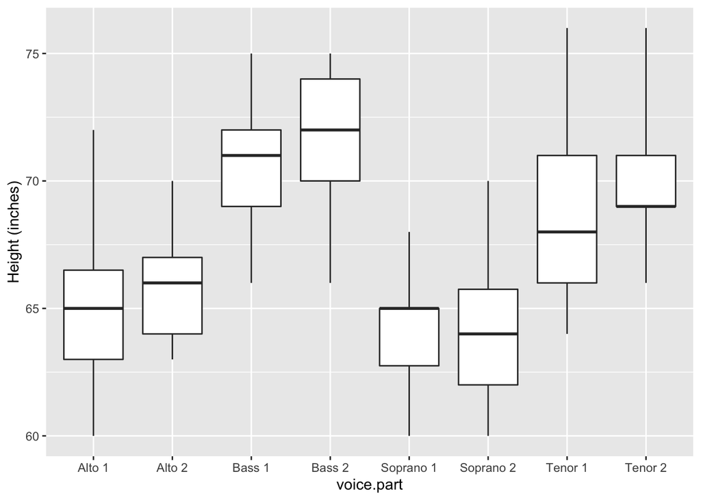

```r
ggplot(singer, aes(x = voice.part, y = height)) +
  geom_boxplot(coef = 10) + ylab("Height (inches)")
```

To draw normal QQ plots of nine simuations of 50 Normal observations:

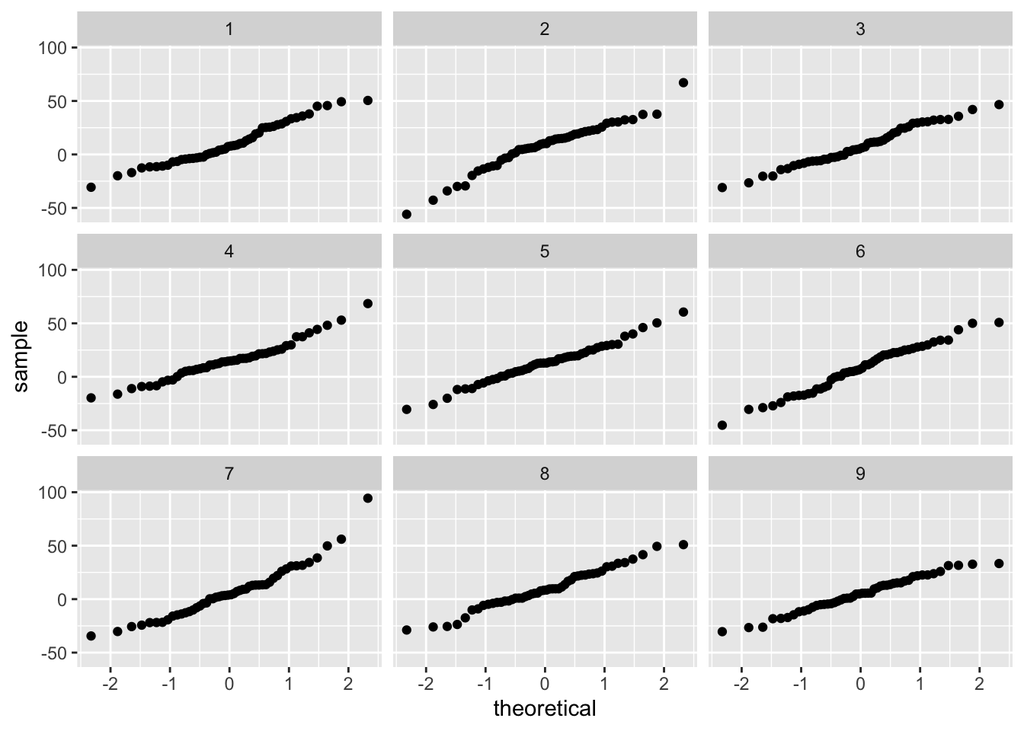

```r
n <- 50
reps <- 9
x <- rnorm(n * reps, mean = 10, sd = 20)
group <- rep(1:reps, each = n)
lots.of.normals <- data.frame(group, x)
ggplot(lots.of.normals, aes(sample = x)) + stat_qq() + facet_wrap(~ group)
```